# Analyse.Rmarkdown

Maroua El Kaddouri

2026-11-12

# Présenation jeu de données

```r
library(carData)
data<-TitanicSurvival
```

```r
head(data)
```

```
##                                 survived    sex     age passengerClass
## Allen, Miss. Elisabeth Walton        yes female 29.0000            1st
## Allison, Master. Hudson Trevor       yes   male  0.9167            1st
## Allison, Miss. Helen Loraine          no female  2.0000            1st
## Allison, Mr. Hudson Joshua Crei       no   male 30.0000            1st
## Allison, Mrs. Hudson J C (Bessi       no female 25.0000            1st
## Anderson, Mr. Harry                  yes   male 48.0000            1st
```

```r
summary(data)
```

```
##  survived      sex           age          passengerClass
##  no :809   female:466   Min.   : 0.1667   1st:323
##  yes:500   male  :843   1st Qu.:21.0000   2nd:277
##                         Median :28.0000   3rd:709
##                         Mean   :29.8811
##                         3rd Qu.:39.0000
##                         Max.   :80.0000
##                         NAs    :263
```

```r
str(TitanicSurvival)
```

```
## 'data.frame':    1309 obs. of  4 variables:
##  $ survived      : Factor w/ 2 levels "no","yes": 2 2 1 1 1 2 2 1 2 1 ...
##  $ sex           : Factor w/ 2 levels "female","male": 1 2 1 2 1 2 1 2 1 2 ...
##  $ age           : num  29 0.917 2 30 25 ...
##  $ passengerClass: Factor w/ 3 levels "1st","2nd","3rd": 1 1 1 1 1 1 1 1 1 1 ...
```

```r
nrow(TitanicSurvival)
```

```
## [1] 1309
```

```r
ncol(TitanicSurvival)
```

```
## [1] 4
```

```r
table(TitanicSurvival$survived)
```

```
##
##  no yes
## 809 500
```

```r
table(TitanicSurvival$sex)
```

```
##
## female   male
##    466    843
```

```r
table(TitanicSurvival$passengerClass)
```

```
##
## 1st 2nd 3rd
## 323 277 709
```

```r
mean(TitanicSurvival$age, na.rm = TRUE)
```

```
## [1] 29.88113
```

```r
median(TitanicSurvival$age, na.rm = TRUE)
```

```
## [1] 28
```

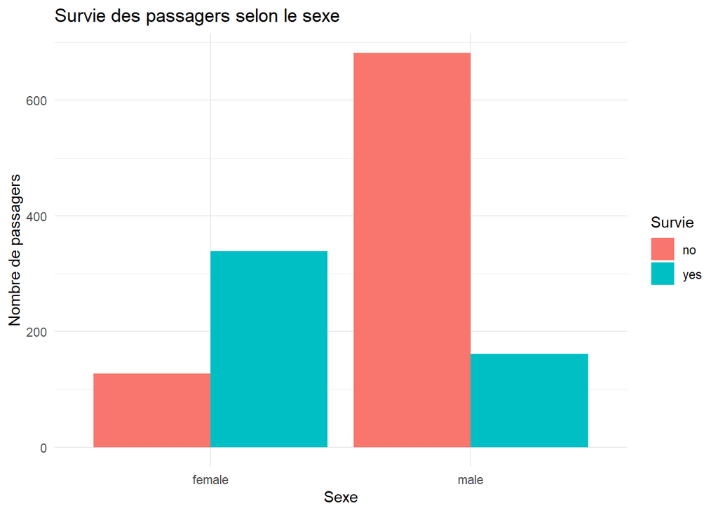

```r
library(ggplot2)

ggplot(TitanicSurvival, aes(x = sex, fill = survived)) +
  geom_bar(position = "dodge") +
  labs(
    title = "Survie des passagers selon le sexe",
    x = "Sexe",
    y = "Nombre de passagers",
    fill = "Survie"
  ) +
  theme_minimal()
```

## Répartition des survivants selon le sexe

Le graphique permet de comparer le nombre de survivants et de non-survivants selon le sexe.

On observe que les femmes ont eu davantage de chances de survivre que les hommes. Une proportion importante des hommes n’a pas survécu au naufrage.

Cela montre que le sexe a été un facteur important dans les chances de survie lors du naufrage du Titanic.

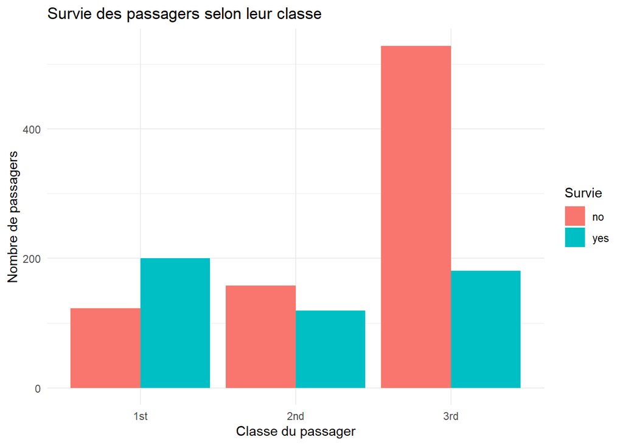

```r
ggplot(TitanicSurvival, aes(x = passengerClass, fill = survived)) +
  geom_bar(position = "dodge") +
  labs(
    title = "Survie des passagers selon leur classe",
    x = "Classe du passager",
    y = "Nombre de passagers",
    fill = "Survie"
  ) +
  theme_minimal()
```

## Répartition des survivants selon la classe

Le graphique montre que la classe du passager semble avoir influencé ses chances de survie.

Les passagers de première classe ont généralement eu davantage de chances de survivre que ceux de deuxième et troisième classe.

Les passagers de troisième classe semblent avoir été plus nombreux à ne pas survivre.

On peut donc constater une différence de survie selon la classe sociale des passagers.

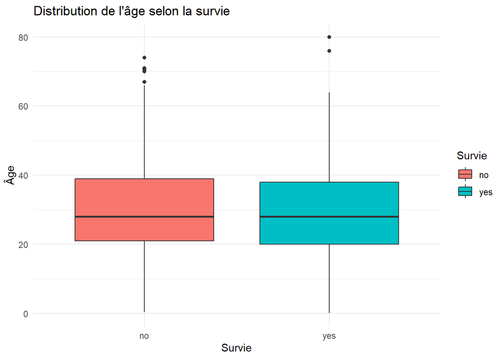

```r
ggplot(TitanicSurvival, aes(x = survived, y = age, fill = survived)) +
  geom_boxplot(na.rm = TRUE) +
  labs(
    title = "Distribution de l'âge selon la survie",
    x = "Survie",
    y = "Âge",
    fill = "Survie"
  ) +
  theme_minimal()
```

## Distribution de l’âge selon la survie

Le diagramme en boîte permet de comparer les âges des passagers ayant survécu et de ceux qui n’ont pas survécu.

Il permet d’observer la médiane, la dispersion des âges ainsi que les éventuelles valeurs atypiques.

On peut ainsi déterminer si l’âge a pu avoir une influence sur les chances de survie des passagers.

Les enfants ont notamment pu bénéficier d’une priorité lors de l’évacuation du Titanic.

```r
library(TitanicPackage)
```

```r
taux_survie(data, "sex")
```

```
## # A tibble: 2 × 2
##   `data[, variable]` TauxSurvie
##   <fct>                   <dbl>
## 1 female                  0.727
## 2 male                    0.191
```

On observe une différence importante entre les femmes et les hommes. Le taux de survie des femmes est d’environ 72,75 %, contre seulement 19,10 % pour les hommes. Cela montre que les femmes ont eu beaucoup plus de chances de survivre au naufrage du Titanic que les hommes. Le sexe semble donc être un facteur déterminant dans les chances de survie.

```r
taux_survie(data,"passengerClass")
```

```
## # A tibble: 3 × 2
##   `data[, variable]` TauxSurvie
##   <fct>                   <dbl>
## 1 1st                     0.619
## 2 2nd                     0.430
## 3 3rd                     0.255
```

On constate que le taux de survie diminue en fonction de la classe du passager. Les passagers de première classe ont le taux de survie le plus élevé avec 61,92 %, suivis de ceux de deuxième classe avec 42,96 %. Enfin, les passagers de troisième classe ont le taux de survie le plus faible avec 25,53 %. Cela suggère que les passagers voyageant dans les classes supérieures avaient davantage de chances de survivre.

Petite conclusion générale : Ces deux résultats montrent que les chances de survie sur le Titanic dépendaient notamment du sexe et de la classe sociale : les femmes et les passagers des classes supérieures étaient davantage favorisés.